# Data and Measurement

# Tutorial 2

In this exercise tutorial, we will tackle various data wrangling and visualization tasks using the dataset named “oxis2013ukda.dta”. The dataset originates from the longest-running academic survey of internet use in Britain, detailing the evolution of internet use from 2003 to the present day. It encompasses nearly 796 variables measuring internet activities, attitudes, and effects. Before proceeding to the exercises, you can review the notes below regarding missing values and tibbles (a data frame-like data structure from the package tidyverse) in R.

**Missing values**

In R, missing values are denoted by ‘NA’ and are not treated as regular values. They can disrupt any expression you attempt to use them in.

To identify missing values, you can employ the function ‘is.na()’. Additionally, when assessing a series of values that may include a missing value, remember to specify ‘na.rm = TRUE’ (the default is ‘FALSE’) to ensure accurate computations.

**Tibbles**

Tibbles are enhanced data frames for streamlined data processing. Tibbles, belonging to the tidyverse ecosystem, offer a modern approach to handling tabular data.

Advantages of tibbles include:

- Limited default output rows for easier large dataset display.
- Retention of original column names without conversion to character vectors.
- Prevention of automatic string-to-factor conversions.
- Preservation of result class when subdividing tibbles with the $ operator.
- Tibbles can be created using functions like tibble() or as_tibble() from the tibble package.

```r
tibble::tibble(
  id = c(1, 2, 3),
  name = c("Alice", "Bob", "Charlie"),
  age = c(25, 30, 35)
)
```

| id | name | age |
| --- | --- | --- |
| 1 | Alice | 25 |
| 2 | Bob | 30 |
| 3 | Charlie | 35 |

You can access columns by name (same as data frames) and access rows and columns by index (same as data frames).

### Exercises - Data wrangling

1. Load the “oxis2013ukda.dta” into the environment. Note that the data is saved in stata file format and you can use “haven” package.

```r
# Load package to read stata file()
library(haven)

# Read the Stata file into R
oxis_data <- read_dta("/Users/msimsek/Desktop/UvA/Teaching/Data_and_Measurement_RMSS/2025/W2/oxis2013ukda.dta")
```

2. Check the class of the dataset. What do tbl_df and tbl mean?

```r
class(oxis_data)
```

```
## [1] "tbl_df"     "tbl"        "data.frame"
```

```r
# tbl_df, a subclass of tbl, is the primary class used with tibbles, and  tbl represents the basic class of tibbles. We can convert it to data.frame using the as.data.frame() function.

oxis_df <- as.data.frame(oxis_data)
```

3. Check the structure of the following four variables:`trmost`, `trgov`, `accmo`, and `dg4`. Display the variable labels separately for each variable (tip: utilize “attr()” function).

```r
vars <- c("trmost","trgov", "accmo", "dg4")
str(oxis_df[, vars])
```

```
## 'data.frame':    2657 obs. of  4 variables:
##  $ trmost: dbl+lbl [1:2657] 2, 1, 3, 3, 3, 3, 3, 3, 4, 3, 2, 2, 3, 2, 3, 3, 1, 3,...
##    ..@ label       : chr "Q.A8 Wd you say most people can be trusted or you can't be too careful?"
##    ..@ format.stata: chr "%30.0g"
##    ..@ labels      : Named num  1 5 NA NA NA NA
##    .. ..- attr(*, "names")= chr [1:6] "1 Can't b2carefl" "5 Most ppl trust" "Don't know" "Legitimate skip" ...
##  $ trgov : dbl+lbl [1:2657] 3, 1, 1, 2, 3, 4, 1, 3, 4, 4, 2, 3, 3, 3, 3, 3, 2, 3,...
##    ..@ label       : chr "Q.A5b How much trust you have in the people running each: The Government"
##    ..@ format.stata: chr "%19.0g"
##    ..@ labels      : Named num  1 5 NA NA NA NA
##    .. ..- attr(*, "names")= chr [1:6] "1 No trust" "5 Total trust" "Don't know" "Legitimate skip" ...
##  $ accmo : dbl+lbl [1:2657]    17, NA(d),    19, NA(d),    20, NA(l),    21,    2...
##    ..@ label       : chr "Q.H3 How long has your household had an Internet connection? 23 ctg"
##    ..@ format.stata: chr "%16.0g"
##    ..@ labels      : Named num  -3 -1 1 2 3 4 5 6 7 8 ...
##    .. ..- attr(*, "names")= chr [1:29] "Don't know" "Legitimate skip" "1 month" "2 months" ...
##  $ dg4   : dbl+lbl [1:2657] 1, 0, 1, 3, 2, 3, 3, 2, 3, 3, 1, 1, 3, 3, 3, 3, 3, 0,...
##    ..@ label       : chr "Q.L1 What is your highest educational or vocational qualification? 4 ctg"
##    ..@ format.stata: chr "%80.0g"
##    ..@ labels      : Named num  0 1 2 3 NA NA NA NA
##    .. ..- attr(*, "names")= chr [1:8] "No qual." "Secondary" "Further ed" "Higher ed." ...
```

```r
# here we see that the variable labels are saved as "label. By using the function attr, we can access the attribute of the variables of interest.
attr(oxis_df$trmost, "label")
```

```
## [1] "Q.A8 Wd you say most people can be trusted or you can't be too careful?"
```

```r
attr(oxis_df$trgov, "label")
```

```
## [1] "Q.A5b How much trust you have in the people running each: The Government"
```

```r
attr(oxis_df$accmo, "label")
```

```
## [1] "Q.H3 How long has your household had an Internet connection? 23 ctg"
```

```r
attr(oxis_df$dg4, "label")
```

```
## [1] "Q.L1 What is your highest educational or vocational qualification? 4 ctg"
```

4. Assign the label “Q.L1 What is your highest educational or vocational qualification? 4 ctg (Generated variable)” to the variable “dg4”.

```r
attr(oxis_df$dg4, "label") <- "Q.L1 What is your highest educational or vocational qualification? 4 ctg (Generated variable)"
attr(oxis_df$dg4, "label")
```

```
## [1] "Q.L1 What is your highest educational or vocational qualification? 4 ctg (Generated variable)"
```

5. What are the numerical values corresponding to the categories of variable dg4?

```r
attr(oxis_df$dg4, "labels")
```

```
##        No qual.       Secondary      Further ed      Higher ed.      Don't know
##               0               1               2               3              NA
## Legitimate skip  Not applicable         Refused
##              NA              NA              NA
```

6. Convert the variable dg4 to a factor and save it as a new variable named “education”. Rename the categories as follows: “No qual.” to “No diploma” “Secondary” to “Secondary education” “Further ed” to “Further education college” “Higher ed.” to “Higher education”

```r
# Convert dg4 to a factor
oxis_df$education <- factor(oxis_df$dg4, levels = c(0, 1, 2, 3),
                              labels = c("No diploma", "Secondary education", "Further education college", "Higher education"))


# Print the levels and labels to see how they were assigned
print(levels(oxis_df$education))
```

```
## [1] "No diploma"                "Secondary education"
## [3] "Further education college" "Higher education"
```

```r
# check whether the levels correspond to correct values in original variable
table(oxis_df$education,oxis_df$dg4, useNA = "ifany")
```

```
##
##                               0   1   2   3 <NA>
##   No diploma                827   0   0   0    0
##   Secondary education         0 877   0   0    0
##   Further education college   0   0 310   0    0
##   Higher education            0   0   0 638    0
##   <NA>                        0   0   0   0    5
```

7. Merge the “Further education college” and “Higher education” categories of the variable education into one category named “More than secondary”.

```r
# Merge "Further education college" and "Higher education college" into "More than secondary"
levels(oxis_df$education)[levels(oxis_df$education) %in% c("Further education college", "Higher education")] <- "More than secondary"

#the above code basically calls the third and fourth levels, i.e.
#OR
#levels(oxis_df$education)[c(3,4)]<- "More than secondary"

# Print the updated levels
print(levels(oxis_df$education))
```

```
## [1] "No diploma"          "Secondary education" "More than secondary"
```

```r
# check whether the levels correspond to correct values in the original variable
table(oxis_df$education,oxis_df$dg4)
```

```
##
##                         0   1   2   3
##   No diploma          827   0   0   0
##   Secondary education   0 877   0   0
##   More than secondary   0   0 310 638
```

8. Determine the number of missing values in the four variables using the functions “is.na()” and “sum()”.

```r
sum(is.na(oxis_df$trmost))
```

```
## [1] 53
```

```r
sum(is.na(oxis_df$trgov))
```

```
## [1] 54
```

```r
sum(is.na(oxis_df$accmo))
```

```
## [1] 856
```

```r
sum(is.na(oxis_df$dg4))
```

```
## [1] 5
```

9. Identify the unique values of `trmost`(You can utilize the “unique()” function or the “table()” function).

```r
table((oxis_df$trmost), useNA = "ifany")
```

```
##
##    1    2    3    4    5 <NA>
##  440  413 1070  579  102   53
```

```r
#OR
unique(oxis_df$trmost)
```

```
## <labelled<double>[6]>: Q.A8 Wd you say most people can be trusted or you can't be too careful?
## [1]     2     1     3     4     5 NA(d)
##
## Labels:
##  value            label
##      1 1 Can't b2carefl
##      5 5 Most ppl trust
##  NA(d)       Don't know
##  NA(l)  Legitimate skip
##  NA(n)   Not applicable
##  NA(r)          Refused
```

10. Compute the mean of `trmost`, `trgov` and `accmo`. Remember to remove NAs while using mean(). Aim to condense the command into one or two lines while obtaining the mean for all three variables (for example use sapply(), or colMeans()).

```r
# Apply mean function with na.rm = TRUE to each variable
vars <- c("trmost","trgov", "accmo")
sapply(oxis_df[, vars], function(x) mean(x, na.rm = TRUE))
```

```
##    trmost     trgov     accmo
##  2.804147  2.305417 17.964464
```

```r
# this would also work: sapply(oxis_df[, c("trmost", "accmo")], mean, na.rm = T)

#Or

colMeans(oxis_df[,vars], na.rm = TRUE)
```

```
##    trmost     trgov     accmo
##  2.804147  2.305417 17.964464
```

### Exercises - Data visualization

1. Visualize `trmost`, `trgov`, `accmo`, and `education` separately. Note: When plotting, ggplot2 ignores NA values and only plots the available data. However, when the variable is a factor, ggplot plots NA as a category.

```r
# Load necessary libraries
library(ggplot2)

# Histograms for trmost, trgov, and accmo
bar_trmost <- ggplot(oxis_df, aes(x = trmost)) +
  geom_bar(fill = "skyblue", color = "black") +
  labs(title = "Distribution of social trust", x = "Social trust", y = "Frequency")

bar_trgov <- ggplot(oxis_df, aes(x = trgov)) +
  geom_bar(fill = "salmon", color = "black") +
  labs(title = "Distribution of institutional trust", x = "institutional trust", y = "Frequency")

bar_accmo <- ggplot(oxis_df, aes(x = accmo)) +
  geom_bar(fill = "lightgreen", color = "black") +
  labs(title = "Distribution of internet duration", x = "Internet duration in months", y = "Frequency")

# Bar plot for education
bar_education <- ggplot(data= oxis_df[!is.na(oxis_df$education), ], aes(x = education)) + geom_bar(fill = "orange", color = "black") +
  labs(title = "Distribution of Education", x = "Education Level", y = "Count")
```

2. Combine the four plots from step 1 (Tip: Utilize cowplot::plot_grid)

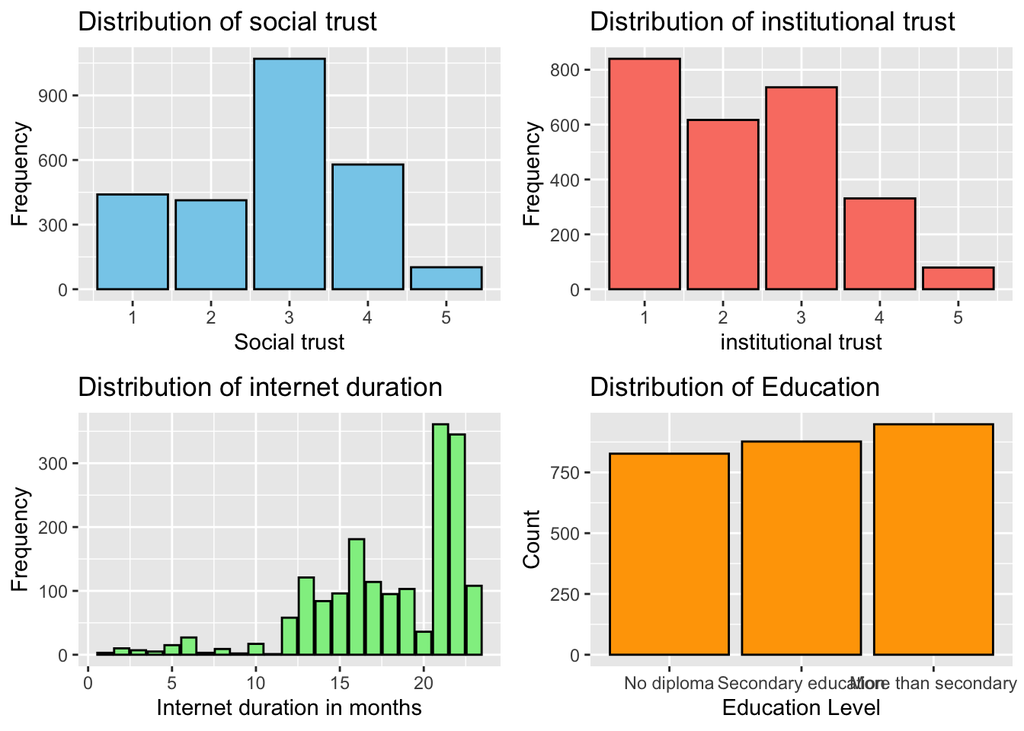

```r
# Combine plots
cowplot::plot_grid(bar_trmost, bar_trgov, bar_accmo, bar_education, ncol = 2)
```

3. Visualize the relationship between trgov and accmo. Would a scatterplot work? If not, what other ways are there to visualize this relationship?

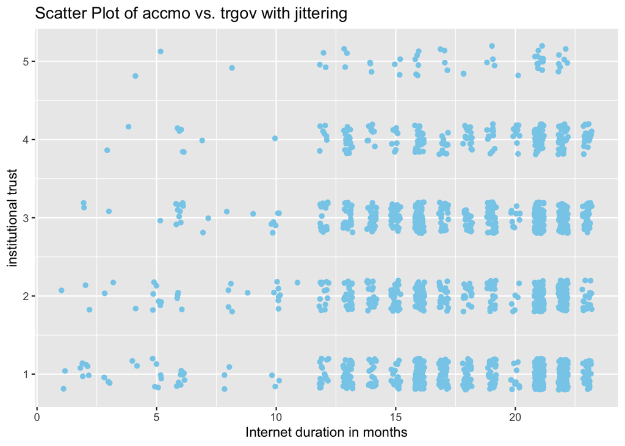

```r
#Scatter plots are one of the best ways to visualize a bivariate relationship. However, they only work if both variables are continuous. If one of the variables is discrete, scatter plots with jittering, conditional density plots or other graphs are often better suited for visualizing relationships.

#The scatter plot with jittering
scatter_trgov <- ggplot(oxis_df, aes(x = accmo, y = trgov)) +
  geom_jitter(width = 0.2, height = 0.2, color = "skyblue") +
  labs(title = "Scatter Plot of accmo vs. trgov with jittering",x = "Internet duration in months", y = "institutional trust")

#Display the plot
print(scatter_trgov)
```

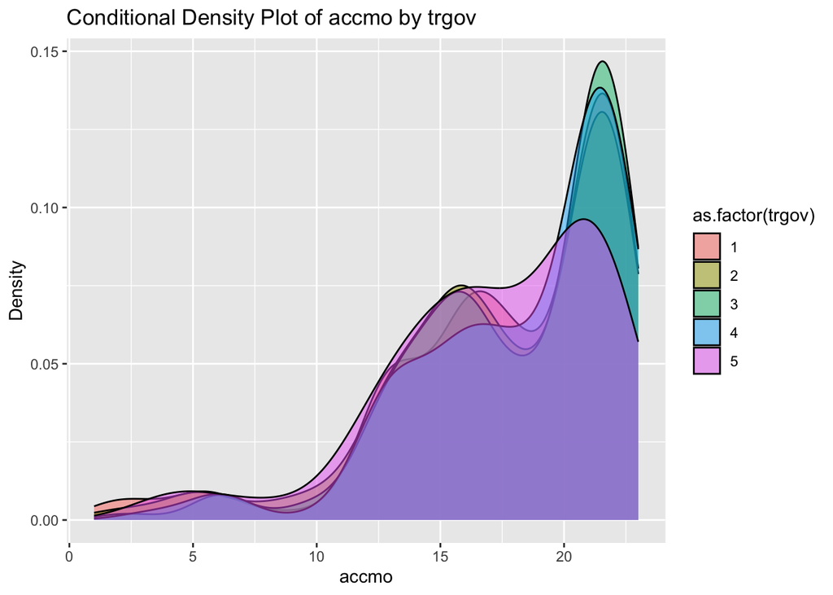

```r
# The conditional density plot for 'accmo' conditioned on 'trgov' in oxis_df
filtered_df<- oxis_df[!is.na(oxis_df$trgov) & !is.na(oxis_df$accmo),]
conditional_density_accmo <- ggplot(data=filtered_df, aes(x = accmo, fill = as.factor(trgov))) +
  geom_density(alpha = 0.5) +
  labs(title = "Conditional Density Plot of accmo by trgov",
       x = "accmo",
       y = "Density")

#Display the plot
conditional_density_accmo
```

4. Visualize the mean internet duration in months for each value of trgov.

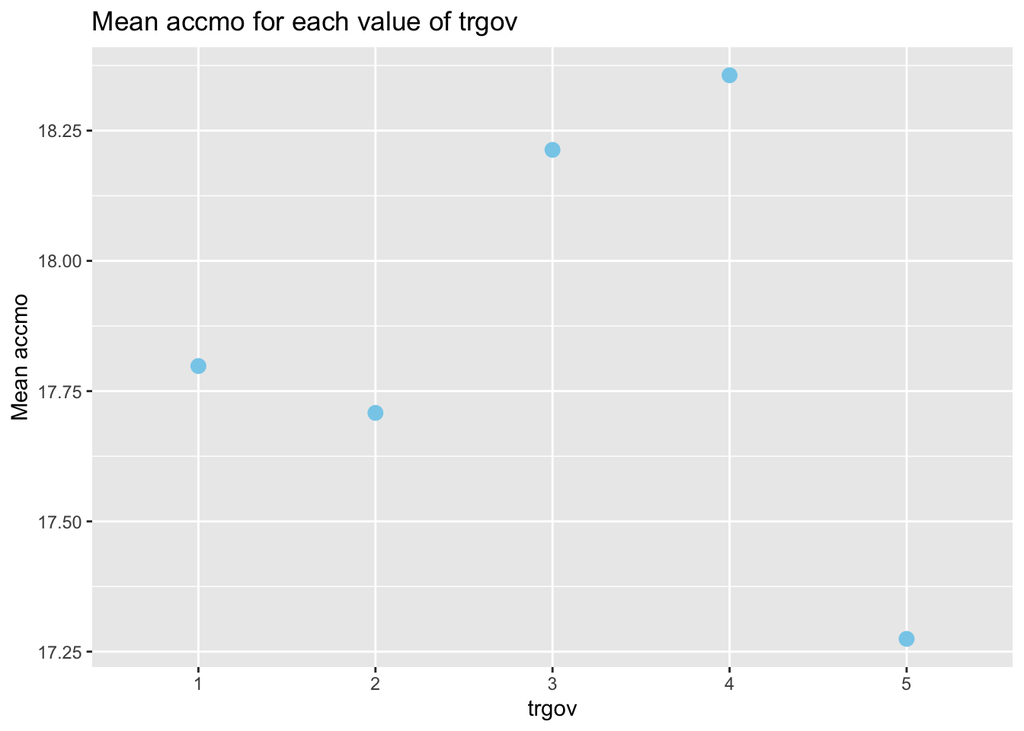

```r
# Calculate mean accmo for each level of trgov
mean_accmo_trgov <- tapply(oxis_df$accmo, oxis_df$trgov, function(x) mean(x, na.rm = T))

# alternatively you can use the pipes from tidyverse
#mean_accmo_trgov <- oxis_df %>%
 # group_by(trgov) %>%
  #summarise(mean_accmo = mean(accmo, na.rm = TRUE))


# Convert the result to a data frame
mean_accmo_trgov <- data.frame(trgov = as.factor(names(mean_accmo_trgov)), mean_accmo = as.numeric(mean_accmo_trgov))


# Create a dot plot using geom_point
ggplot(mean_accmo_trgov, aes(x = trgov, y = mean_accmo)) +
  geom_point(color = "skyblue", size = 3) +
  labs(title = "Mean accmo for each value of trgov",
       x = "trgov",
       y = "Mean accmo")
```

5. Recode trmost into two categories (high trust vs low trust) and visualize the relationship between education (3 categories) and this new trmost variable.

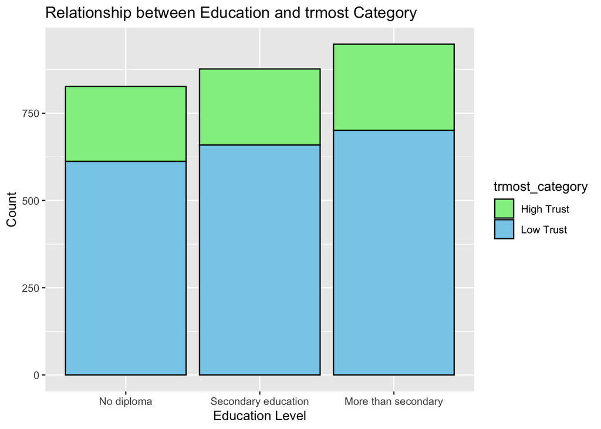

```r
# recode trmost into two categories into a new variable trmost_category
oxis_df$trmost_category <- ifelse(oxis_df$trmost %in% c(4, 5), "High Trust", "Low Trust")

#alternative
# oxis_df <- oxis_df %>%
  # mutate(trmost_category = ifelse(trmost %in% c(4, 5), "High Trust", "Low Trust"))

#Visualize the relationship between education and new categorical trmost variable

# Stacked bar plot for education and new trmost category
stacked_bar <- ggplot(data=na.omit(oxis_df[,c("education", "trmost_category")]), aes(x = education, fill = trmost_category)) +
  geom_bar(position = "stack", color = "black") +
  labs(title = "Relationship between Education and trmost Category", x = "Education Level", y = "Count") +
  scale_fill_manual(values = c("Low Trust" = "skyblue", "High Trust" = "lightgreen"))

# Display stacked bar plot
print(stacked_bar)
```

6. Using the 1.5 * IQR (Interquartile Range) rule, determine the number of outliers present in the variable ‘accmo’. You can calculate this manually. To observe the smallest and largest values, you can utilize the table() function or display the head and tail of the sorted variable using head() and tail() functions.

```r
summary(oxis_df$accmo)
```

```
##    Min. 1st Qu.  Median    Mean 3rd Qu.    Max.    NA's
##    1.00   15.00   19.00   17.96   22.00   23.00     856
```

```r
#IQR = 22-15 = 7
#7*1.5 = 10.5
#An observation is an outlier if it falls more than 1.5(IQR) above the upper
#quartile or more than 1.5(IQR) below the lower quartile. So the observations smaller than 4.5 and larger than 32.5 are outliers.

#See the frequency of smallest and largest values
table(oxis_df$accmo)
```

```
##
##   1   2   3   4   5   6   7   8   9  10  11  12  13  14  15  16  17  18  19  20
##   3  10   7   5  15  27   3   9   2  17   1  58 121  84  96 181 114  95 103  36
##  21  22  23
## 361 345 108
```

```r
# 25 outliers, 4 values: 1,2,3,4 months

#alternatively:
# Sort the data in ascending order of accmo
#oxis_df_sorted <- oxis_df[order(oxis_df$accmo), ]

# Print the first and last rows of the sorted dataset
# head(oxis_df_sorted$accmo, 30)
# tail(oxis_df_sorted$accmo, 30)
```

7. Generate a boxplot for the variable `accmo` and verify if the number of outliers you identified in step 6 corresponds to the outliers depicted in this plot.

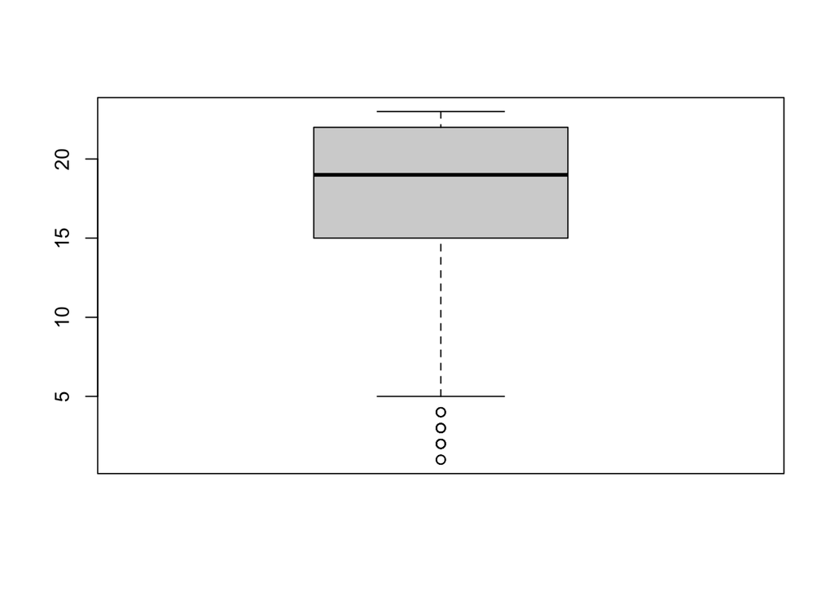

```r
# Create a boxplot for accmo
boxplot(oxis_df$accmo)
```

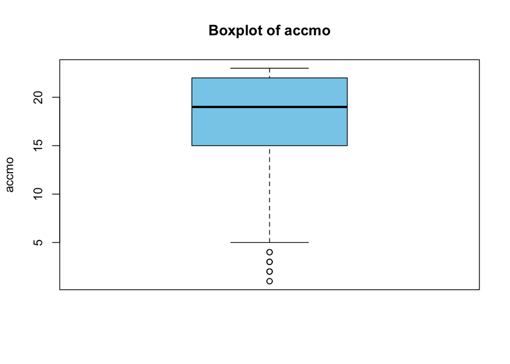

```r
boxplot(oxis_df$accmo,
        main = "Boxplot of accmo",
        ylab = "accmo",
        col = "skyblue",
        border = "black")
```

```r
# Note that due to overlapping points, the boxplot may display only a limited number of dots as outliers, which could represent multiple outlier values.To obtain the number of outliers, we can refer to the output generated by the boxplot function:

#save the boxplot into an object
boxplot_accmo <- boxplot(oxis_df$accmo,
        main = "Boxplot of accmo",
        ylab = "accmo",
        col = "skyblue",
        border = "black")

str(boxplot_accmo)
```

```
## List of 6
##  $ stats: num [1:5, 1] 5 15 19 22 23
##  $ n    : num 1801
##  $ conf : num [1:2, 1] 18.7 19.3
##  $ out  : num [1:25] 2 1 4 2 4 3 3 3 2 1 ...
##  $ group: num [1:25] 1 1 1 1 1 1 1 1 1 1 ...
##  $ names: chr ""
```

```r
# Extract the outlier values in accmo
outliers <- boxplot_accmo$out


# Count the number of outliers
num_outliers <- length(outliers)

# Print the number of outliers
print(num_outliers)
```

```
## [1] 25
```